# temp_final-analysis_JAN2025

### Question 1 results

Models that were used (WITHOUT INTERACTION): model.1red, model.2red, model.3red.

CTMAX - highest max temps found in P. latipinna and lowest max temps in X. nigrensis - Highest temps in P. latipinna at 39 deg C - Lowest temps in X. nigrensis at around 34.5 deg C - no significant difference between males and females, but species significantly differ

CTMIN - lowest min temp in G. affinis at 4.5 deg C and highest min temps in X. nigrensis at around 10 deg C - no significant difference between males and females, but species significantly differ

TOT.TEMP - highest total temperatures that all our target fish could have was found in G. affinis from 32 to almost 34 deg C - lowesst total temp range found in X. nigrensis at around 25 deg C - again, no significant difference between males and females - total thermal range between G. affinis and P. latipinna are not significantly different, but both are significantly different to the total thermal range of X. nigrensis.

## Question 2

Regardless of the size differences, do the two males and female of the swordtail species differ in their thermal tolerance (max, min, tot) due to mating strategies?

```r
swordtail_1 <- rawTempData[rawTempData$Species =="X. nigrensis",]
```

Also, since females don’t have a mating strategy, and the size of males corresponds with their mating strategy (large=courting, small=coercive), I think it would be best/easiest for our model to create a new sex column with three factors: female, male.large, and male.small. That way we won’t have to worry about one of our groups (ie females) not having a factor for mating strategy. SO let’s create a new column. The size.cat column is basically what we want, since it has a value for the two males and for females, but let’s make some more intuitive labels.

```r
swordtail_1$sex.2 <- swordtail_1$Size.cat #duplicates column

#replace values in new column
swordtail_1$sex.2 <- gsub("large", "male.large", swordtail_1$sex.2)
swordtail_1$sex.2 <- gsub("small", "male.small", swordtail_1$sex.2)
swordtail_1$sex.2 <- gsub("reg", "female", swordtail_1$sex.2)


#added as character, changing to factor

swordtail_1$sex.2 <- as.factor(swordtail_1$sex.2)
swordtail_1$sex.2 <- factor(swordtail_1$sex.2, levels = c("male.large", "male.small", "female"))
```

Now for the model

### CTmax

Remember, to address mating style and sex we’ll use the new column, sex.2

```r
#wfull model with size; NOTE: there is no interaction effect here, since sex and mating style are just one factor now.

model.4a <- glm(CTmax.C ~ sex.2 + Size.mm, data = swordtail_1)



#reduced model without size

model.4b <- glm(CTmax.C ~ sex.2, data = swordtail_1)
Anova(model.4b)
```

```
## Analysis of Deviance Table (Type II tests)
##
## Response: CTmax.C
##       LR Chisq Df Pr(>Chisq)
## sex.2  0.88418  2     0.6427
```

```r
#Model selection
model.sel(model.4a, model.4b)
```

```
## Model selection table
##          (Int) sex.2  Siz.mm df  logLik AICc delta weight
## model.4b 35.59     +          4 -42.118 93.8  0.00  0.689
## model.4a 39.28     + -0.1082  5 -41.464 95.4  1.59  0.311
## Models ranked by AICc(x)
```

```r
  ##model.4b selected
```

#### Summary of final chosen model

```r
## replace A with either the full or reduced model name
summary(model.4b)
```

```
##
## Call:
## glm(formula = CTmax.C ~ sex.2, data = swordtail_1)
##
## Coefficients:
##                 Estimate Std. Error t value Pr(>|t|)
## (Intercept)      35.5900     0.3925  90.681   <2e-16 ***
## sex.2male.small  -0.4266     0.5374  -0.794    0.434
## sex.2female      -0.4187     0.4753  -0.881    0.386
## ---
## Signif. codes:  0 '***' 0.001 '**' 0.01 '*' 0.05 '.' 0.1 ' ' 1
##
## (Dispersion parameter for gaussian family taken to be 1.078266)
##
##     Null deviance: 30.067  on 29  degrees of freedom
## Residual deviance: 29.113  on 27  degrees of freedom
## AIC: 92.236
##
## Number of Fisher Scoring iterations: 2
```

```r
#this may give you an error, since there's been a change in the syntax for the lme4 package since version 4.1.2. If you get an error, remove the '#' and run the code below
## summary(full, use.hessian = FALSE)

model.4b %>%
  emmeans(pairwise~sex.2) %>%
  summary()
```

```
## $emmeans
##  sex.2      emmean    SE df lower.CL upper.CL
##  male.large   35.6 0.392 27     34.8     36.4
##  male.small   35.2 0.367 27     34.4     35.9
##  female       35.2 0.268 27     34.6     35.7
##
## Confidence level used: 0.95
##
## $contrasts
##  contrast                estimate    SE df t.ratio p.value
##  male.large - male.small   0.4266 0.537 27   0.794  0.7100
##  male.large - female       0.4187 0.475 27   0.881  0.6568
##  male.small - female      -0.0079 0.455 27  -0.017  0.9998
##
## P value adjustment: tukey method for comparing a family of 3 estimates
```

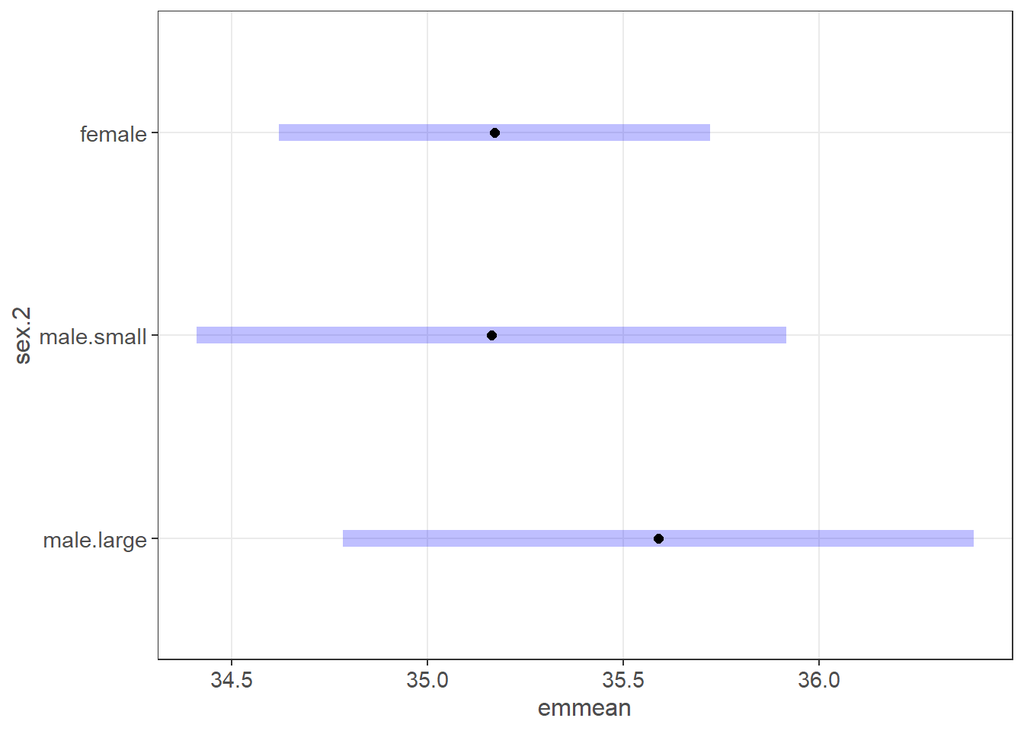

```r
model.4b %>%
  emmeans(pairwise~sex.2) %>%
  plot() #will plot group means with 95% confidence intervals
```

### CTmin

Repeat above for CTmin

```r
#full model with size; NOTE: there is no interaction effect here, since sex and mating style are just one factor now.

model.5a <- glm(CTmin.C ~ sex.2 + Size.mm, data = swordtail_1)



#reduced model without size

model.5b <- glm(CTmin.C ~ sex.2, data = swordtail_1)

#Model selection
model.sel(model.5a, model.5b)
```

```
## Model selection table
##           (Int) sex.2   Siz.mm df  logLik AICc delta weight
## model.5b  9.806     +           4 -28.705 67.0  0.00  0.694
## model.5a 12.120     + -0.06791  5 -28.076 68.7  1.64  0.306
## Models ranked by AICc(x)
```

```r
  ##model.5b selected
```

#### Summary of final chosen model

```r
## replace A with either the full or reduced model name
summary(model.5b)
```

```
##
## Call:
## glm(formula = CTmin.C ~ sex.2, data = swordtail_1)
##
## Coefficients:
##                 Estimate Std. Error t value Pr(>|t|)
## (Intercept)      9.80571    0.25098  39.069   <2e-16 ***
## sex.2male.small  0.33554    0.34367   0.976    0.338
## sex.2female     -0.07138    0.30396  -0.235    0.816
## ---
## Signif. codes:  0 '***' 0.001 '**' 0.01 '*' 0.05 '.' 0.1 ' ' 1
##
## (Dispersion parameter for gaussian family taken to be 0.4409478)
##
##     Null deviance: 12.796  on 29  degrees of freedom
## Residual deviance: 11.906  on 27  degrees of freedom
## AIC: 65.411
##
## Number of Fisher Scoring iterations: 2
```

```r
#this may give you an error, since there's been a change in the syntax for the lme4 package since version 4.1.2. If you get an error, remove the '#' and run the code below
## summary(full, use.hessian = FALSE)


model.5b %>%
  emmeans(pairwise~sex.2) %>%
  summary()
```

```
## $emmeans
##  sex.2      emmean    SE df lower.CL upper.CL
##  male.large   9.81 0.251 27     9.29     10.3
##  male.small  10.14 0.235 27     9.66     10.6
##  female       9.73 0.171 27     9.38     10.1
##
## Confidence level used: 0.95
##
## $contrasts
##  contrast                estimate    SE df t.ratio p.value
##  male.large - male.small  -0.3355 0.344 27  -0.976  0.5978
##  male.large - female       0.0714 0.304 27   0.235  0.9701
##  male.small - female       0.4069 0.291 27   1.400  0.3552
##
## P value adjustment: tukey method for comparing a family of 3 estimates
```

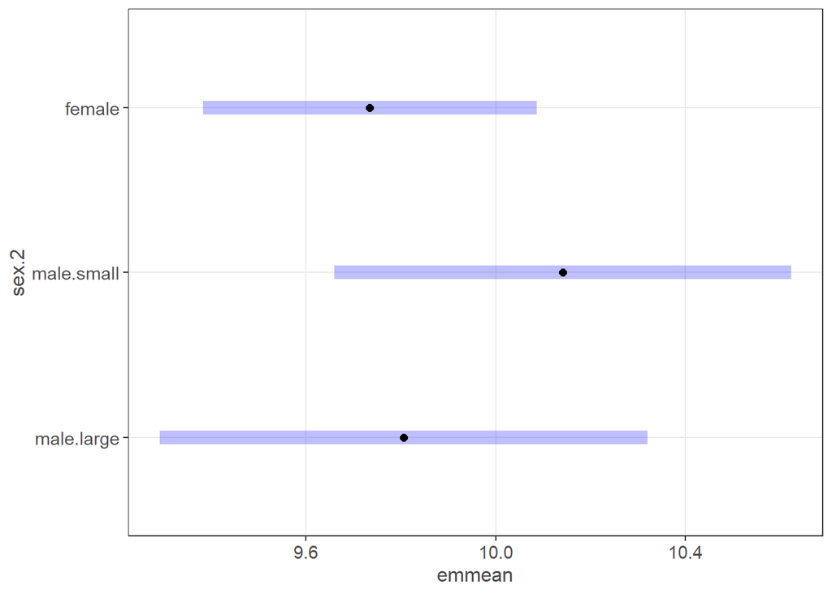

```r
model.5b %>%
  emmeans(pairwise~sex.2) %>%
  plot() #will plot group means with 95% confidence intervals
```

### Tot temp

Repeat above for Tot temp

```r
#full model with size; NOTE: there is no interaction effect here, since sex and mating style are just one factor now.

model.6a <- glm(T.tot ~ sex.2 + Size.mm, data = swordtail_1)



#reduced model without size

model.6b <- glm(T.tot ~ sex.2, data = swordtail_1)

#Model selection
model.sel(model.6a, model.6b)
```

```
## Model selection table
##          (Int) sex.2   Siz.mm df  logLik  AICc delta weight
## model.6b 25.78     +           4 -46.602 102.8  0.00    0.8
## model.6a 27.16     + -0.04034  5 -46.536 105.6  2.77    0.2
## Models ranked by AICc(x)
```

```r
  ##model.6b selected
```

#### Summary of final chosen model

```r
## replace A with either the full or reduced model name
summary(model.6b)
```

```
##
## Call:
## glm(formula = T.tot ~ sex.2, data = swordtail_1)
##
## Coefficients:
##                 Estimate Std. Error t value Pr(>|t|)
## (Intercept)      25.7843     0.4558  56.575   <2e-16 ***
## sex.2male.small  -0.7621     0.6241  -1.221    0.233
## sex.2female      -0.3473     0.5519  -0.629    0.535
## ---
## Signif. codes:  0 '***' 0.001 '**' 0.01 '*' 0.05 '.' 0.1 ' ' 1
##
## (Dispersion parameter for gaussian family taken to be 1.453982)
##
##     Null deviance: 41.452  on 29  degrees of freedom
## Residual deviance: 39.258  on 27  degrees of freedom
## AIC: 101.2
##
## Number of Fisher Scoring iterations: 2
```

```r
#this may give you an error, since there's been a change in the syntax for the lme4 package since version 4.1.2. If you get an error, remove the '#' and run the code below
## summary(full, use.hessian = FALSE)


model.6b %>%
  emmeans(pairwise~sex.2) %>%
  summary()
```

```
## $emmeans
##  sex.2      emmean    SE df lower.CL upper.CL
##  male.large   25.8 0.456 27     24.8     26.7
##  male.small   25.0 0.426 27     24.1     25.9
##  female       25.4 0.311 27     24.8     26.1
##
## Confidence level used: 0.95
##
## $contrasts
##  contrast                estimate    SE df t.ratio p.value
##  male.large - male.small    0.762 0.624 27   1.221  0.4513
##  male.large - female        0.347 0.552 27   0.629  0.8055
##  male.small - female       -0.415 0.528 27  -0.786  0.7148
##
## P value adjustment: tukey method for comparing a family of 3 estimates
```

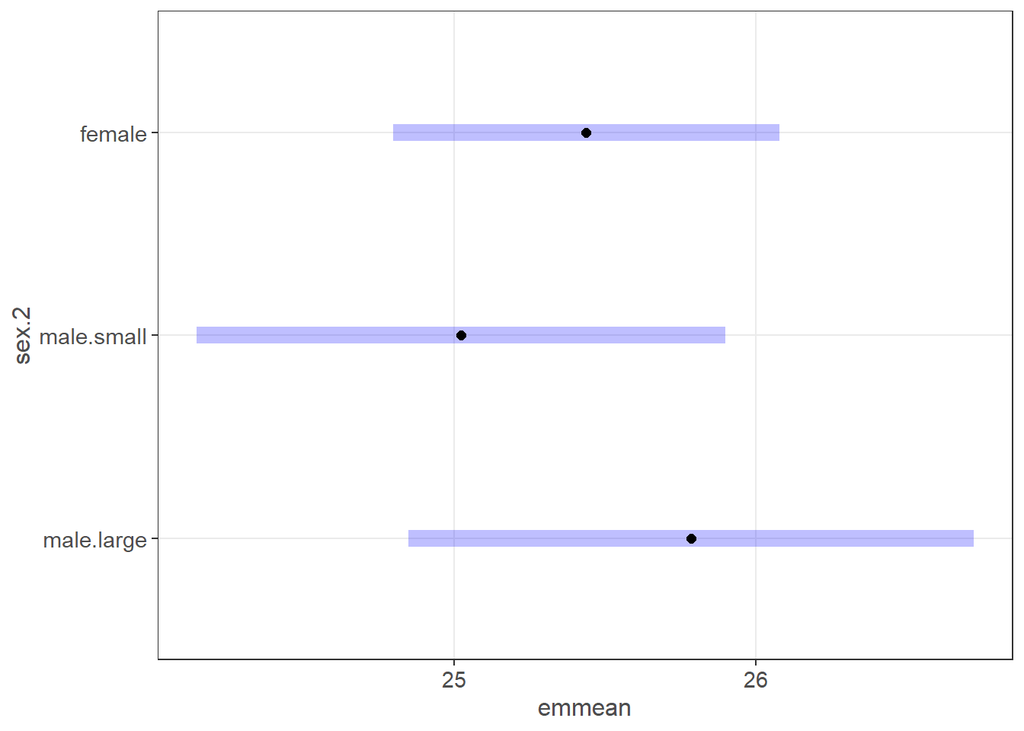

```r
model.6b %>%
  emmeans(pairwise~sex.2) %>%
  plot() #will plot group means with 95% confidence intervals
```

### Check normality of final models

See tab above for the code

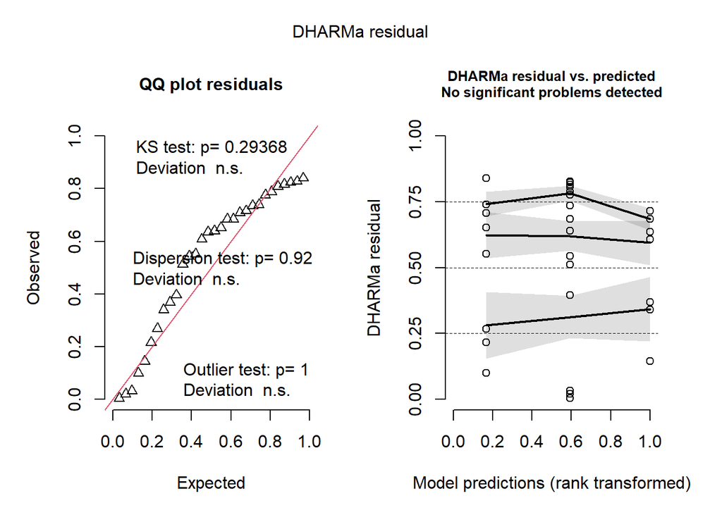

```r
############ CTmax ###########
#Simulated residuals plots using DHARMa package


simulationOutput <- simulateResiduals(model.4b)

plot(simulationOutput)
```

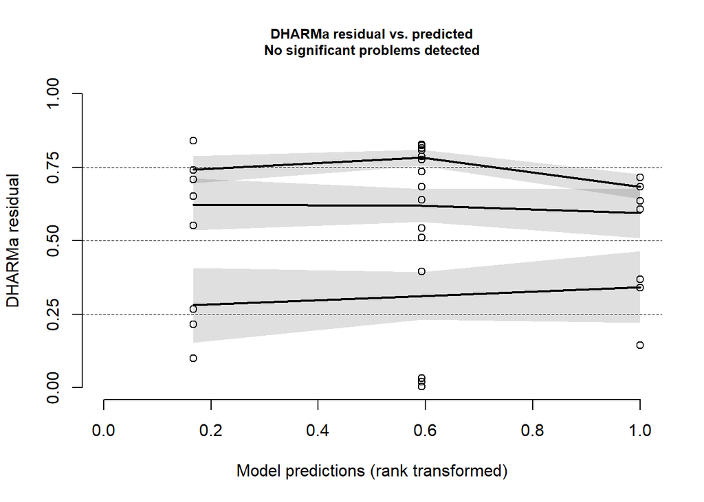

```r
plotResiduals(simulationOutput)
```

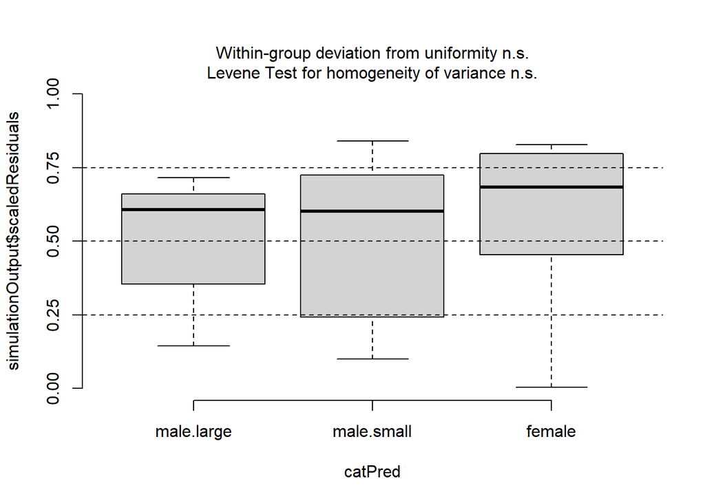

```r
plotResiduals(simulationOutput, form = swordtail_1$sex.2)
```

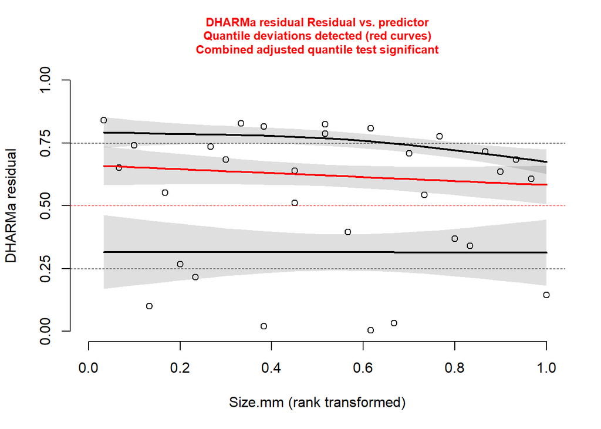

```r
plotResiduals(simulationOutput, form = swordtail_1$Size.mm)
```

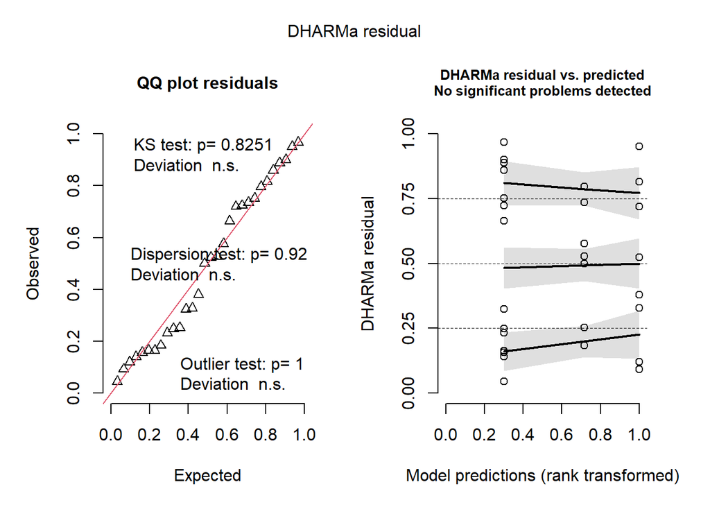

```r
  #while there is some slight deviation from normality in the Size.mm variable (significant quantile test), we don't use this factor in our final model so I won't be correcting for it.


########### CTmin ###########
#Simulated residuals plots using DHARMa package


simulationOutput <- simulateResiduals(model.5b)

plot(simulationOutput)
```

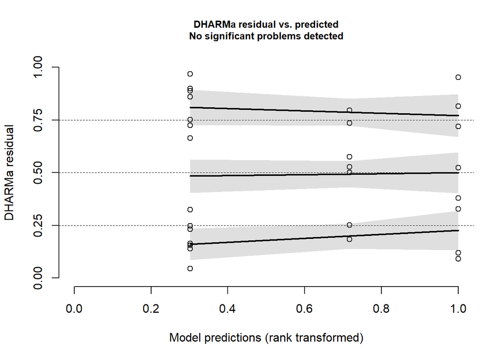

```r
plotResiduals(simulationOutput)
```

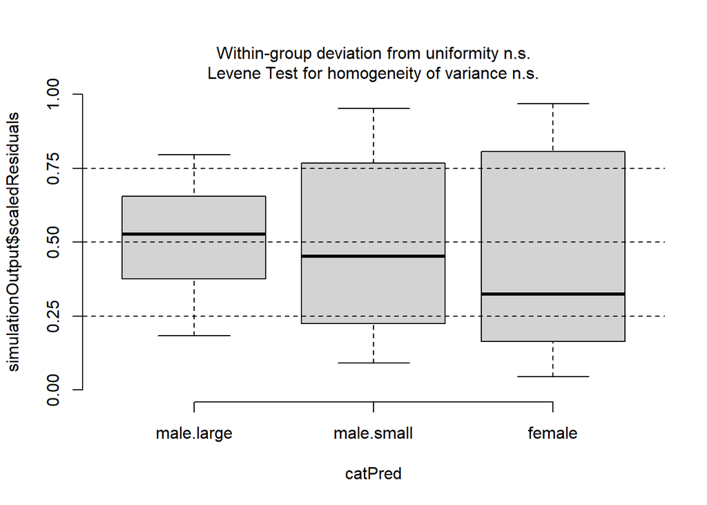

```r
plotResiduals(simulationOutput, form = swordtail_1$sex.2)
```

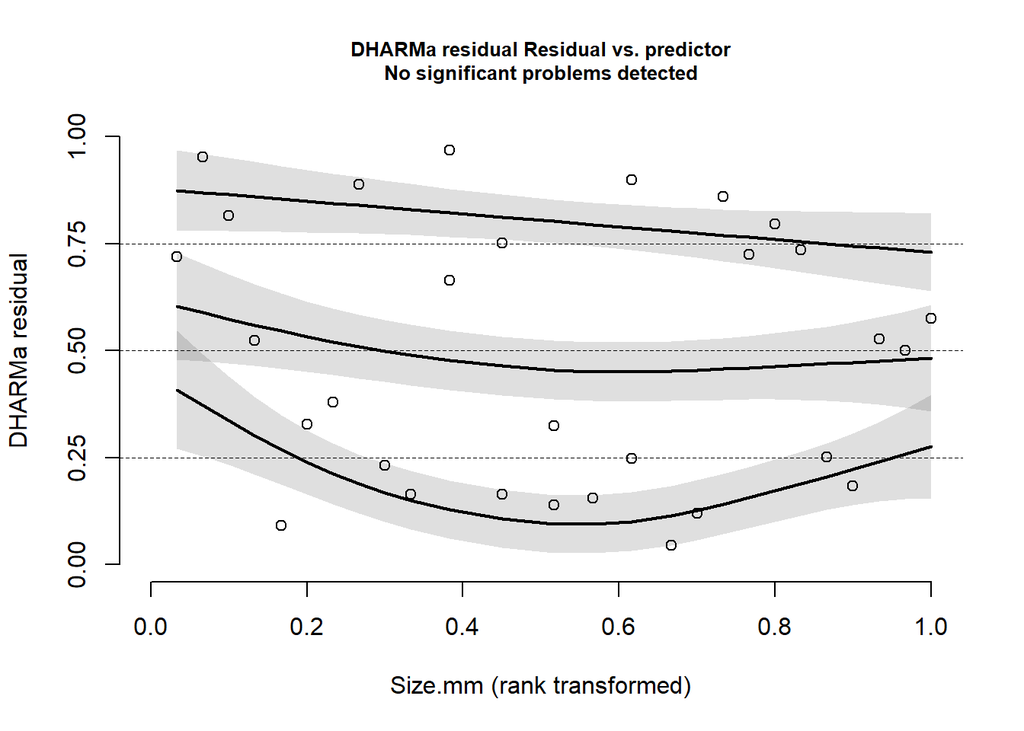

```r
plotResiduals(simulationOutput, form = swordtail_1$Size.mm)
```